# Project-WriteUp

Lala Ng

April 22, 2015

### I. Cleaning & Prepocessing Data

In this assignment, we will require **caret** and **randomForest** library to workout the solution. In addition, preprocessing the raw file is trivial to remove noise data

```r
# Load up file and preprocessing
train <- read.csv(file = destTrainFile, header = TRUE, sep = ",", na.strings = c("NA","#DIV/0!", ""), stringsAsFactors = FALSE)
test <- read.csv(file = destTestFile, header = TRUE, sep = ",", na.strings = c("NA","#DIV/0!", ""), stringsAsFactors = FALSE)

# Delete columns with all missing values
# 1. We find col that has total number of NA equals 0
train_select_col <- colSums(is.na(train)) == 0
test_select_col <- colSums(is.na(test)) == 0

# 2. Filter selected column.
train <- train[,train_select_col]
test <- test[,test_select_col]
train$classe <- as.factor(train$classe)

# 3. user_name, raw_timestamp_part_1, raw_timestamp_part_3
# cvtd_timestamp, new_window, num_window are not particularly # useful.
# Remove it
train <- train[,-c(1:7)]
test <- test[,-c(1:7)]
```

Data is now clean and ready to be extracted. It’s often useful to take a look at initial data for me. From the histogram, **class A** frequently occurs while **class D** has the least number of occurences.

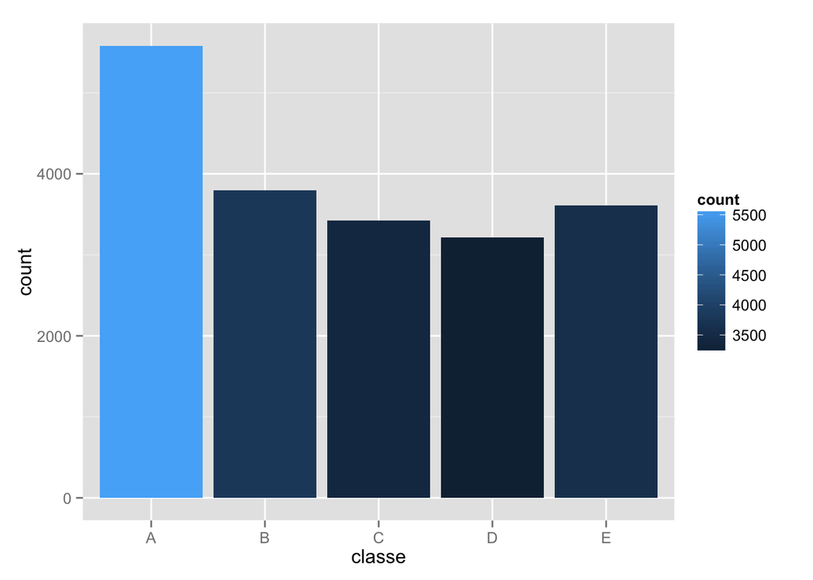

```r
ggplot(train, aes( x = classe)) +
        geom_histogram( aes(fill=..count..))
```

### II. Trainning and Testing

We are given **train set** and **test set**, predicting a **class** in test set would require a prediction model to be built first. In this task, we will build up model by using random forest for classification provided from packet **randomForest** on our **classe feature** .

**Warning: Random Forest takes approximately 3 hours on my computer to finish computing**

```
## [1] "Test Sample of Training Data"
```

```
##  Accuracy
## 0.9949021
```

```r
# Predict new data
preds <- predict(modFit, newdata = test)
# Filter and evaluate our hypothesis
print("Prediction on 20 cases")
```

```
## [1] "Prediction on 20 cases"
```

```r
preds
```

```
##  [1] B A B A A E D B A A B C B A E E A B B B
## Levels: A B C D E
```